# Pertemuan 5-Pembangkitan Bilangan Acak

Author

Fitri Diana Musa

Published

September 17, 2026

# A. Recall Materi

1. Fungsi `plot()` pada base R dapat digunakan untuk membuat berbagai jenis grafik, dan argumen `type = "l"` digunakan untuk menampilkan grafik dalam bentuk garis.  
   ☐ Benar ☐ Salah
2. Argumen `pch` digunakan untuk mengatur ukuran titik pada grafik, sedangkan `cex` digunakan untuk menentukan bentuk titik.  
   ☐ Benar ☐ Salah
3. Perintah `par(mfrow = c(2, 2))` digunakan untuk menampilkan maksimal empat grafik dalam satu tampilan dengan susunan 2 baris dan 2 kolom.  
   ☐ Benar ☐ Salah
4. Pada `ggplot2`, variabel yang ingin dipetakan ke warna, bentuk, atau ukuran berdasarkan nilai data sebaiknya dituliskan di dalam fungsi `aes()`.  
   ☐ Benar ☐ Salah
5. Kode `geom_point(color = "blue")` berarti warna titik akan berubah secara otomatis mengikuti kategori suatu variabel pada data.  
   ☐ Benar ☐ Salah
6. Fungsi `facet_wrap()` pada `ggplot2` dapat digunakan untuk memisahkan sebuah grafik menjadi beberapa panel berdasarkan kategori suatu variabel.  
   ☐ Benar ☐ Salah
7. Fungsi `ggsave()` dapat digunakan untuk menyimpan grafik `ggplot2` ke dalam file seperti PNG atau PDF.  
   ☐ Benar ☐ Salah

# B. Random Generators in R

Sebagai salah satu bahasa pemrograman yang hadir karena kebutuhan akan komputasi statistik, R telah menyiapkan banyak fungsi untuk membangkitkan data berdasarkan sebaran. Fungsi peluang suatu sebaran dalam R ditandai dengan prefix sebagai berikut:

| Prefix | Makna | Definisi Sederhana |
| --- | --- | --- |
| **`r-`** | **random** | Membangkitkan data acak dari suatu distribusi. |
| **`d-`** | **density** | Menghitung nilai kepadatan atau peluang pada suatu nilai x. |
| **`p-`** | **probability** | Menghitung peluang kumulatif sampai nilai x. |
| **`q-`** | **quantile** | Mencari nilai x berdasarkan peluang kumulatif tertentu. |

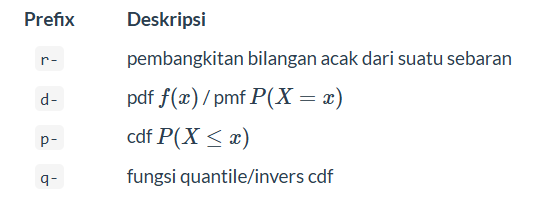

Tabel Distribusi Peluang dan Parameter di R:

[output not shown]

Contoh:

```r
rnorm(10, mean = 50, sd = 5)
```

```
 [1] 52.88694 49.70176 48.69386 41.07473 55.02284 48.79200 47.35136 47.46373
 [9] 47.71695 52.86685
```

Makna : membangkitkan 10 bilangan acak dari distribusi Normal dengan rata-rata 50 dan simpangan baku 5.

```r
runif(100, min = 0, max = 10)
```

```
  [1] 1.89340473 6.77857269 8.13276347 6.24180804 0.62819374 6.19450610
  [7] 0.02148726 6.46057289 5.43298172 4.13796800 4.69925372 6.94897829
 [13] 3.12864504 9.98427059 5.38683190 7.66009655 5.66277230 1.88414724
 [19] 3.68951866 4.58904531 0.37856483 4.18016332 1.92656361 8.01196838
 [25] 6.31189468 4.59600413 4.21786595 9.20935228 9.69140218 1.07308547
 [31] 2.03904027 9.52760468 2.56579936 6.05204714 1.11515088 9.00135824
 [37] 9.96973036 5.49067364 9.78798796 4.35935326 3.37133930 9.08895729
 [43] 1.18216246 5.22236046 0.97535721 7.22624819 2.15285437 3.59964135
 [49] 4.32346185 3.21225926 2.91284152 0.22409342 9.93510579 0.75080663
 [55] 7.84602740 5.57863971 3.42553791 0.25996998 2.36120633 6.33408978
 [61] 3.97580276 6.06733055 3.15263714 2.80297224 8.03953894 7.32346996
 [67] 5.62420347 3.15305177 8.16314464 6.40109581 8.17239413 6.76192124
 [73] 8.96812337 0.79138125 8.73186438 0.33986233 9.02048997 2.13043713
 [79] 4.95499186 9.52935161 2.14656891 6.29521332 1.28000175 7.44451921
 [85] 4.20655843 5.21523448 5.10186543 7.73708851 7.14403324 4.40870932
 [91] 6.21313328 9.41955784 0.24057689 5.36548252 1.83389689 6.37381425
 [97] 7.14547747 1.86666473 9.92592156 1.81499373
```

```r
rbinom(100, size = 10, prob = 0.5)
```

```
  [1] 6 2 5 7 5 5 5 4 6 5 6 3 5 4 6 7 3 7 3 5 7 5 5 6 3 8 7 4 7 5 3 7 4 3 7 7 3
 [38] 7 8 4 4 5 6 7 5 5 3 5 7 4 5 5 4 4 4 3 6 3 3 5 7 3 5 7 5 7 4 3 4 2 6 7 4 7
 [75] 5 4 3 3 6 6 5 4 6 4 5 5 5 6 4 5 4 4 5 4 7 3 5 4 6 5
```

```r
rpois(100, lambda = 3)
```

```
  [1] 3 1 2 4 7 4 4 2 2 5 2 2 3 3 5 4 4 4 5 4 2 1 1 5 4 0 5 3 2 4 0 2 3 7 1 4 1
 [38] 5 4 0 3 1 5 3 1 3 6 6 0 5 4 2 5 2 2 2 2 3 5 2 2 3 0 1 2 5 4 2 4 2 1 4 4 4
 [75] 5 6 0 3 1 3 2 0 0 5 3 3 0 4 3 1 2 3 4 2 4 4 2 0 3 5
```

Lalu apakah tabel tersebut hanya bisa untuk membangkitkan bilangan acak? atau hanya untuk prefix r- saja?

Jawabannya tidak, tabel distribusi tersebut dan dapat digunakan untuk prefix lainnya.

Contoh:

```r
rnorm(10, mean = 50, sd = 5)
```

```
 [1] 48.98597 42.19981 51.76429 54.11410 50.32044 48.45375 54.64080 49.73125
 [9] 47.06724 46.43072
```

```r
dnorm(50, mean = 50, sd = 5)
```

```
[1] 0.07978846
```

```r
pnorm(50, mean = 50, sd = 5)
```

```
[1] 0.5
```

```r
qnorm(0.95, mean = 50, sd = 5)
```

```
[1] 58.22427
```

Dari contoh tersebut, yang menjadi poin perbedaannya adalah argumen pertama:

| Prefix | Argumen pertama | Makna |
| --- | --- | --- |
| `r-` | `n` | jumlah bilangan acak yang ingin dibangkitkan |
| `d-` | `x` | nilai x yang ingin dihitung kepadatan/peluangnya |
| `p-` | `q` | nilai batas untuk menghitung peluang kumulatif |
| `q-` | `p` | nilai probabilitas untuk mencari kuantil |

Beberapa teknik umum pembangkitan bilangan acak di R:

## 1. Inverse Transform Method

**Inverse Transform Method** adalah teknik membangkitkan bilangan acak dari suatu distribusi tertentu dengan memanfaatkan bilangan acak Uniform U(0,1).

Ide dasarnya:

$$U \sim U(0,1)$$

kemudian nilai U tersebut dimasukkan ke **invers fungsi distribusi kumulatif (CDF)**:

$$X = F^{-1}(U)$$

Hasil X akan mengikuti distribusi yang diinginkan.

Algoritma Inverse Transform Method adalah sebagai berikut:

1. Tentukan distribusi yang ingin dibangkitkan dan CDF-nya,

   $$F(x) = P(X \leq x)$$
2. Bangkitkan bilangan acak

   $$U \sim U(0,1)$$
3. Bentuk persamaan:

   $$U = F(X)$$
4. Cari invers CDF sehingga diperoleh:

   $$X = F^{-1}(U)$$
5. Nilai X yang diperoleh merupakan bilangan acak dari distribusi yang diinginkan.

#### Contoh

Bangkitkan bilangan acak yang berdistribusi $exponential(2)$ dengan Inverse Transform Method, yang amatannya berjumlah $10$.

#### 1. Tentukan CDF

CDF dari distribusi Eksponensial adalah:

$$F(x) = 1-e^{-\lambda x}$$

CDF dari $\text{Exponential}(2):$

$$F(x) = 1-e^{-2x}$$

#### 2. Ganti $F(x)$ dengan $U$

Karena:

$$U = F(X)$$

maka:

$$U = 1 - e^{-2X}$$

#### 3. Cari $X$

Mulai dari:

$$U = 1 - e^{-2X}$$

Pindahkan:

$$e^{-2X} = 1-U$$

Gunakan algoritma:

$$-2X = \ln(1-U)$$

Sehingga:

$$X = -\frac{1}{2}\ln(1-U)$$

Secara umum:

$$\boxed{
X = -\frac{1}{\lambda}\ln(1-U)
}$$

Inilah invers CDF dari distribusi Eksponensial.

Contoh dengan angka:

Misalnya dari Uniform diperoleh:

$$U = 0.6$$

dan:

$$\lambda = 2$$

Maka:

$$X = -\frac{1}{2}\ln(1-0.6)$$

$$X = -\frac{1}{2}\ln(0.4)$$

karena:

$$\ln(0.4) \approx -0.9163$$

maka:

$$X = -\frac{1}{2}(-0.9163)$$

$$\boxed{X \approx 0.458}$$

Artinya bilangan Uniform:

$$U = 0.6$$

setelah melalui *inverse transform* berubah menjadi:

$$X \approx 0.458$$

yang merupakan bilangan acak dari distribusi Eksponensial dengan $\lambda = 2$.

Implementasi di R:

Di soal disebutkan bahwa kita akan membangkitkan 10 bilangan acak, maka:

```r
set.seed(123)

# Bangkitkan bilangan Uniform
u <- runif(10)

# Parameter
lambda <- 2

# Inverse Transform
x <- -log(1 - u) / lambda

x
```

```
 [1] 0.16954209 0.77630468 0.26295011 1.07286505 1.41061464 0.02331342
 [7] 0.37549990 1.11475582 0.40085086 0.30496835
```

Membangkitan dengan Fungsi Bawaan R:

```r
set.seed(123)
y <- rexp(10,rate = 2)
y
```

```
 [1] 0.42172863 0.28830514 0.66452743 0.01578868 0.02810549 0.15825061
 [7] 0.15711365 0.07263340 1.36311823 0.01457672
```

Menampilkan Histogram di R untuk Melihat Perbedaan antara Invers Transform dengan Fungsi Bawaan R:

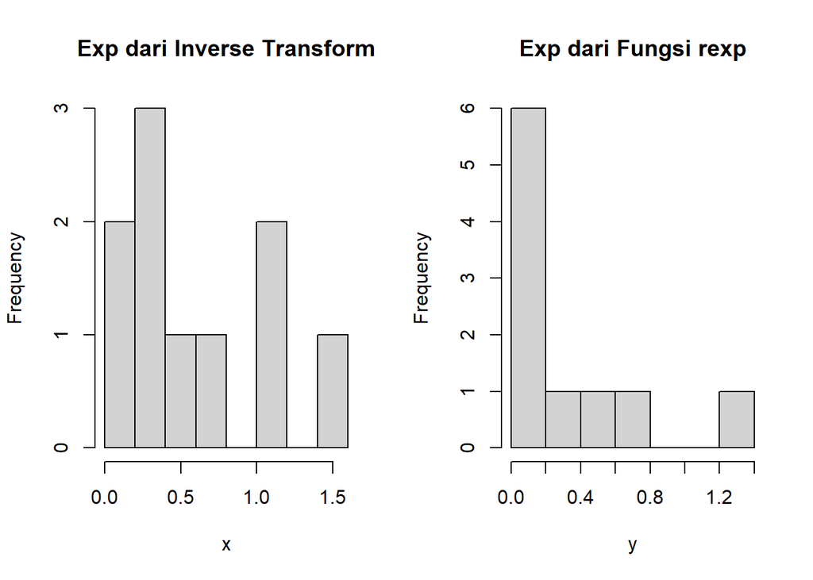

```r
par(mfrow=c(1,2))
hist(x,main="Exp dari Inverse Transform")
hist(y,main="Exp dari Fungsi rexp")
```

## 2. Acceptance-Rejection Method

**Acceptance-Rejection Method** adalah teknik pembangkitan bilangan acak dengan cara membangkitkan **calon nilai** dari suatu distribusi yang lebih mudah dibangkitkan, kemudian calon tersebut diperiksa apakah **diterima atau ditolak**.

Algoritma Acceptance-Rejection Method adalah sebagai berikut:

1. Tentukan distribusi target dengan PDF:

$$f(x)$$

2. Pilih distribusi proposal $Y$ yang mudah dibangkitkan dengan PDF:

$$g(y)$$

3. Tentukan konstanta:

$$c = \max_y \frac{f(y)}{g(y)}$$

4. Bangkitkan kandidat:

$$Y \sim g(y)$$

5. Bangkitkan:

$$U \sim Uniform(0,1)$$

6. Hitung:

$$\frac{f(Y)}{c\,g(Y)}$$

7. Jika:

$$U \leq \frac{f(Y)}{c\,g(Y)}$$

maka terima:

$$X = Y$$

8. Jika tidak memenuhi syarat, tolak $Y$, kemudian ulangi langkah 4-7 sampai jumlah bilangan acak yang diinginkan terpenuhi.

#### Contoh:

Bangkitkan peubah acak $X \sim Beta(2,2)$ yang memiliki fungsi PDF:

$$f(x) = 6x(1-x), 0<x<1$$

dengan menggunakan Acceptance-Rejection Method sebanyak 100 amatan. Kemudian gambarkan histrogramnya!

Penyelesaian:

#### 1. Tentukan distribusi target

Distribusi target adalah:

$$X \sim Beta(2,2)$$

dengan PDF:

$$f(x) = 6x(1-x), \qquad 0 < x < 1$$

#### 2. Tentukan distribusi proposal

Pilih:

$$Y \sim U(0,1)$$

karena memiliki domain yang sama dengan distribusi target, yaitu antara 0 dan 1.

PDF dari $Y$ adalah:

$$g(y) = 1, \qquad 0 \leq y \leq 1$$

#### 3. Hitung Nilai $c$

Nilai $c$ dicari dari:

$$c = \max_y \frac{f(y)}{g(y)}$$

Karena:

$$f(y) = 6y(1-y)$$

dan:

$$g(y) = 1$$

Maka misalkan saja $h(y) = \frac{f(y)}{g(y)}$, sehingga

$$h(y) = \frac{6y(1-y)}{1} = 6y(1-y)$$

Untuk mencari nilai maksimum dari $h(y)$ maka kita harus menyelesaikan persamaan:

$$\frac{d h(y)}{dy}=0$$

Dengan menggunakan aturan perkalian pada turunan maka didapatkan:

$$\begin{aligned}
6(1-y)-6y &= 0 \\
6-6y-6y &= 0 \\
6-12y &= 0 \\
y &=\frac{1}{2} \\
\end{aligned}$$

Subtitusi $y=\frac{1}{2}$ ke $h(y)$ sehingga didapatkan:

$$h(\frac{1}{2}) = 6(\frac{1}{2})(1-\frac{1}{2})=\frac{3}{2}$$

sehingga nilai $c=1.5$

#### 4. Tentukan aturan penerimaan

Syarat *Acceptance-Rejection* adalah:

$$u \leq \frac{f(y)}{c\,g(y)}$$

Substitusikan:

$$f(y) = 6y(1-y)$$

$$g(y) = 1$$

dan:

$$c = 1.5$$

sehingga:

$$u
\leq
\frac{6y(1-y)}{1.5(1)}$$

atau:

$$\boxed{u \leq 4y(1-y)}$$

Jadi:

- Jika
  $$u \leq 4y(1-y)$$

  maka $Y$ **diterima** dan dijadikan $X$.
- Jika tidak, $Y$ **ditolak** dan proses diulang.

Proses dilakukan sampai diperoleh **100 nilai** $X$ yang diterima.

#### 5. Implementasi di R

```r
# Tentukan banyaknya amatan
n <- 100

# Tentukan fungsi h(y) dan cari nilai c
h <- function(y) {
  6 * y * (1 - y)
}

hasil_opt <- optimize(
  f = h,
  interval = c(0, 1),
  maximum = TRUE
)
hasil_opt
```

```
$maximum
[1] 0.5

$objective
[1] 1.5
```

```r
# Nilai y saat fungsi mencapai maksimum
cmax <- hasil_opt$maximum

# Nilai maksimum fungsi = konstanta c
copt <- hasil_opt$objective

# Tampilkan hasil
cmax
```

```
[1] 0.5
```

```r
copt
```

```
[1] 1.5
```

```r
# Proses Acceptance-Rejection
set.seed(123)

x <- numeric(0)

while (length(x) < n) {

  # Bangkitkan kandidat Y ~ Uniform(0,1)
  y <- runif(1, min = 0, max = 1)

  # Bangkitkan U ~ Uniform(0,1)
  u <- runif(1, min = 0, max = 1)

  # PDF target
  f_y <- 6 * y * (1 - y)

  # PDF proposal
  g_y <- 1

  # Aturan Acceptance-Rejection
  if (u <= f_y / (copt * g_y)) {
    x <- c(x, y)
  }}


# Tampilkan beberapa hasil Acceptance-Rejection
head(x)
```

```
[1] 0.2875775 0.4089769 0.9404673 0.5281055 0.5514350 0.6775706
```

```r
# Cek jumlah amatan
length(x)
```

```
[1] 100
```

Versi 2:

```r
# Banyaknya amatan
n <- 100

set.seed(123)

# Tempat menyimpan hasil
x <- numeric(0)

while (length(x) < n) {

  # Bangkitkan Y ~ Uniform(0,1)
  y <- runif(1, min = 0, max = 1)

  # Bangkitkan U ~ Uniform(0,1)
  u <- runif(1, min = 0, max = 1)

  # Acceptance-Rejection
  if (u <= 4 * y * (1 - y)) {
    x <- c(x, y)
  }
}

# Tampilkan hasil
head(x)
```

```
[1] 0.2875775 0.4089769 0.9404673 0.5281055 0.5514350 0.6775706
```

```r
# Cek jumlah amatan
length(x)
```

```
[1] 100
```

Membangkitan dengan Fungsi Bawaan R:

```r
set.seed(123)

# fungsi rbeta
z <- rbeta(100, shape1 = 2, shape2 = 2)

# beberapa hasil pertama
head(z)
```

```
[1] 0.3449138 0.4352767 0.8756111 0.5198841 0.5364345 0.8994396
```

```r
# jumlah amatan
length(z)
```

```
[1] 100
```

Menampilkan histogram di R

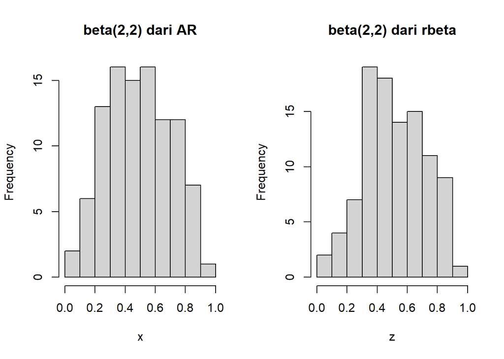

```r
par(mfrow=c(1,2))
hist(x,main="beta(2,2) dari AR")
hist(z,main="beta(2,2) dari rbeta")
```

## 3. Direct Transformation

**Direct Transformation Method** adalah teknik pembangkitan bilangan acak dengan cara **mentransformasikan satu atau beberapa peubah acak yang mudah dibangkitkan menggunakan rumus tertentu**, sehingga diperoleh peubah acak dengan distribusi yang diinginkan.

Hubungan dan Transformasi Antar Distribusi Peluang

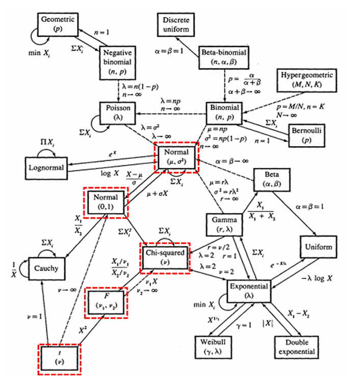

Contoh:

Bangkitkan 1000 peubah acak $Y\sim N(0,1)$. Dengan menggunakan Direct Transformation $X=Y^2$, bangkitkan peubah acak $X\sim\chi^2(1)$, kemudian bandingkan histogram hasil transformasi dengan PDF teoritis distribusi Chi-square.

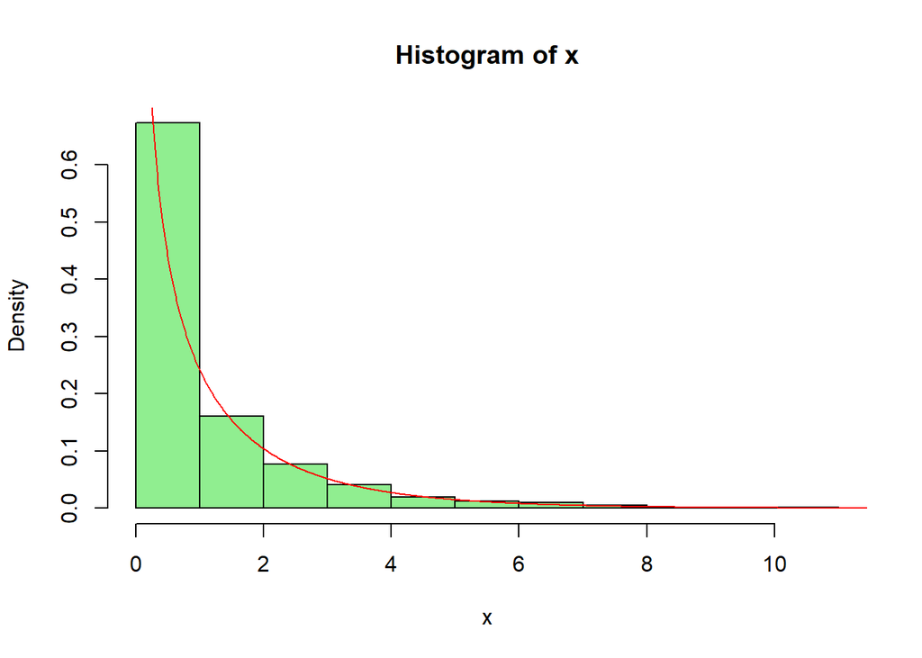

```r
# membangkitkan 1000 bilangan acak dari distribusi Normal standar
y <- rnorm(1000)

# mentransformasikan setiap nilai Y dengan cara dikuadratkan.
x <- y^2

# membuat histogram hasil transformasi X
hist(x, prob=T, col="lightgreen")

# membuat deret nilai dari 0 sampai 13 dengan selang 0,01
sbx <- seq(0,13,0.01)

# menambahkan kurva PDF teoritis distribusi Chi-square dengan derajat bebas 1 pada histogram
lines(sbx, dchisq(sbx,df=1), col="red")
```

## 4. Latihan Soal

1. Bangkitkan bilangan acak yang berdistribusi $Uniform(a=2,b=5)$ dengan **Inverse Transform Method** sebanyak 100 amatan. Bandingkan hasilnya dengan fungsi bawaan R `runif()` menggunakan histogram.
2. Bangkitkan bilangan acak yang berdistribusi $Exponential(\lambda=3)$ dengan **Inverse Transform Method** sebanyak 100 amatan. Bandingkan hasilnya dengan fungsi bawaan R `rexp()` menggunakan histogram.
3. Bangkitkan 1000 bilangan acak dari distribusi dengan PDF

   $f(x)=2x,\qquad 0<x<1$

   menggunakan **Acceptance-Rejection Method** dengan distribusi proposal $Uniform(0,1)$.
4. Bangkitkan 1000 bilangan acak dari distribusi dengan PDF

   $f(x)=3x^2,\qquad 0<x<1$

   menggunakan **Acceptance-Rejection Method** dengan distribusi proposal $Uniform(0,1)$. Tentukan nilai konstanta $c$, kemudian gambarkan histogram hasil pembangkitannya.